# (Ford GoBike Visualizations)

## by (Abdulrahman Alghaligah)

## Investigation Overview

> In this Investigation, I will look at the characteristics for the duration of trips, the main focus was on age, gender and type of user.

## Dataset Overview

> The dataset contains information about trips in the bike system in February 2019, the dataset has information like user gender and duration of trip etc.

## (The duration of trip by user type)

> The chart is to show you which type of users finsih the trip more faster.And it looks likle subscribers are faster.

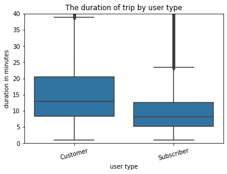

## (The duration of trip by age)

> The chart shows which age is most frequent in using our bikes also it illustrates which age spend more time in trips. It looks like younger ages spend more time and the most frequent range of age is between 20-40.

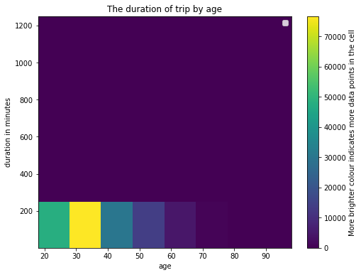

## (The duration of the trip by age in both subscribers and customers type)

> The next chart shows the most age spending time in trips for both user types. It seems like there is no difference in types, all younger ages users spending more duration in the trips for all types.

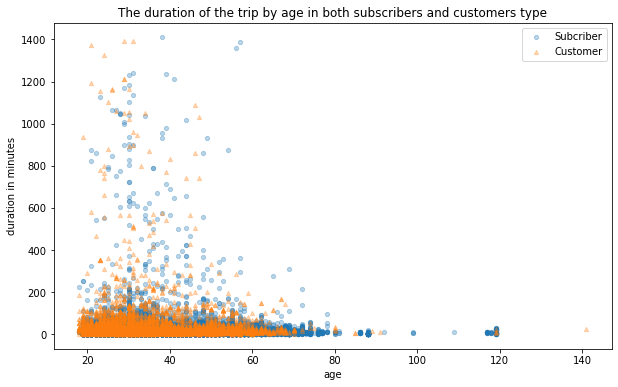